# R Notebook

Read in the labelled object Run the correlation comparison between the total scRNA per FACS pop and the AB levels Calculate the proportion of the cell types from the orginal labels UMAP of the cell POPS merged UMAP of the subtypes labelled

```r
library(Seurat)
library(dplyr)
library('reshape')
library("ggplot2")
```

Read in the lableled object single cell sequencing

```r
pathway <- "/Users/rhalenathomas/Documents/Data/scRNAseq/PhenoID/scRNAseqSorted/objs/"
seu.sc <- readRDS(paste(pathway, "CombinedLabeledMarkers14102022.RDS"))
```

Read in the Flow Cytometry data

```r
output_path = "/Users/rhalenathomas/Documents/Data/FlowCytometry/PhenoID/Analysis/PaperFigures/PostSortGatingPops/"
seu.fc <- readRDS(paste(output_path,"june10postSort.seu.RDS", sep = ""))
unique(seu.fc$GatedPop)
```

```
[1] Astrocytes RadialGlia Neurons1   Neurons2
Levels: Astrocytes RadialGlia Neurons1 Neurons2
```

Marker list

```r
marker.ab <- c("CD24","CD56","CD29","CD15","CD184","CD133","CD71","CD44","GLAST","AQP4","HepaCAM", "CD140a","O4")

marker.genes <-c("CD24","NCAM1","ITGB1","FUT4","CXCR4","PROM1","TFRC","CD44","SLC1A3","AQP4","HEPACAM", "PDGFRA","NKX6-2")
```

Make the expression matrixes

```r
seu.sc <- ScaleData(object = seu.sc, features = rownames(seu.sc))
```

Calculate correlation between two matrixes

```r
df.cor
```

```
           Astrocytes RadialGlia   Neurons1    Neurons2
Astrocytes  0.5553328  0.1522878 -0.4517431 -0.18064326
RadialGlia  0.1305815  0.4451073 -0.3314321  0.05559489
Neurons1   -0.4098105 -0.3016957  0.4534910  0.05175022
Neurons2   -0.4858683 -0.1624758  0.3770386  0.23752196
```

```r
write.csv(df.cor, paste(output_path,"CorrelationsFCscRNAseq.csv"))
```

Plot the heatmap Figure 6A

```r
# need to melt the matrix
longData<- melt(df.cor)
head(longData)
```

|  | X1 | X2 | value |
| --- | --- | --- | --- |
| 1 | Astrocytes | Astrocytes | 0.5553328 |
| 2 | RadialGlia | Astrocytes | 0.1305815 |
| 3 | Neurons1 | Astrocytes | -0.4098105 |
| 4 | Neurons2 | Astrocytes | -0.4858683 |
| 5 | Astrocytes | RadialGlia | 0.1522878 |
| 6 | RadialGlia | RadialGlia | 0.4451073 |

```r
colnames(longData) <- c("FC","scRNA","R2")

ggplot(longData, aes(x=scRNA,y=FC, fill =R2)) + geom_tile() +
  scale_fill_gradient2(low = "#075AFF",
                       mid = "#FFFFCC",
                       high = "#FF0000") +
   guides(fill = guide_colourbar(label = TRUE,
                                ticks = FALSE)) + theme_bw() +
  coord_fixed()  +scale_x_discrete(expand=c(0,0))+
  scale_y_discrete(expand=c(0,0))+ theme(text = element_text(size=16, colour = "black"),
        axis.text.x = element_text(size = 18, colour = "black", angle = 90), axis.text.y = element_text(size= 18, colour = "black"))  + xlab('scRNAseq') + ylab('Flow Cytometry')

output_path <- "/Users/rhalenathomas/Documents/Projects_Papers/PhenoID/ForFigures/scRNA/"

pdf(paste(output_path,"FC_scRNA_correlationOct16.pdf"), width = 8, height = 5)
```

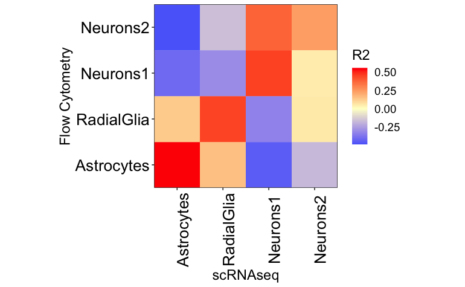

```r
ggplot(longData, aes(x=scRNA,y=FC, fill =R2)) + geom_tile() +
  scale_fill_gradient2(low = "#075AFF",
                       mid = "#FFFFCC",
                       high = "#FF0000", midpoint = 0, limit = c(-0.5,0.5)) +
   guides(fill = guide_colourbar(label = TRUE,
                                ticks = FALSE)) + theme_bw() +
  coord_fixed()  +scale_x_discrete(expand=c(0,0)) +
  scale_y_discrete(expand=c(0,0)) +
  theme(text = element_text(size=16, colour = "black"),
        axis.text.x = element_text(size = 16, colour = "black", angle = 90), axis.text.y = element_text(size= 16, colour = "black"))  + xlab('scRNAseq') + ylab('Flow Cytometry')

dev.off()
```

Compare proportions of cells in each FACS pop - Figure 6B

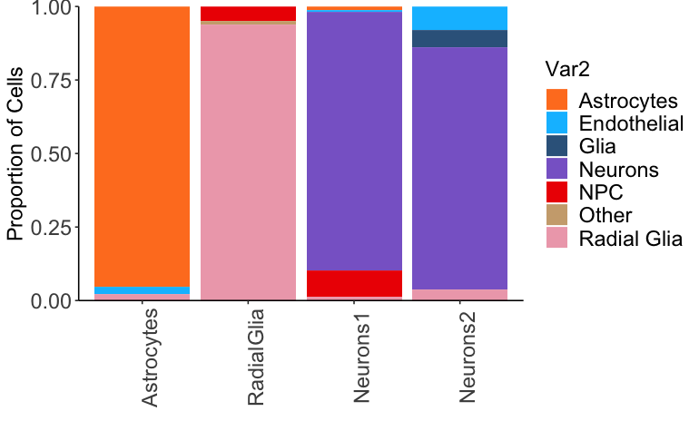

Make a table of cell types

```r
library(stringr)
library(reshape)

# for original cell types


df.r <- reshape(df, idvar = "Var2", timevar = "Var1", direction = "wide")
dat1 <- df.r
dat1[] <- lapply(dat1[], function(x){
  # Check if the column is numeric
  if (is.numeric(x)){
    return(x/sum(x)*100)
  } else{
    return(x)
  }
})
dat1
```

|  | Var2 | Freq.Neurons2 | Freq.Neurons1 | Freq.Astrocytes | Freq.RadialGlia |
| --- | --- | --- | --- | --- | --- |
| 1 | Astrocytes | 0.000000 | 1.15 | 95.433333 | 0.00 |
| 5 | Endothelial | 7.951248 | 0.65 | 2.400000 | 0.00 |
| 9 | Glia | 6.035984 | 0.00 | 0.000000 | 0.00 |
| 13 | Neurons | 82.298317 | 87.90 | 0.000000 | 0.00 |
| 17 | NPC | 0.000000 | 9.00 | 0.000000 | 5.00 |
| 21 | Other | 0.000000 | 0.00 | 0.000000 | 1.15 |
| 25 | Radial Glia | 3.714452 | 1.30 | 2.166667 | 93.85 |

```r
write.csv(dat1, paste(output_path,"proportionofCelltypesin4pops.csv"))

### for new main cell types

df.r <- reshape(df.3, idvar = "Var2", timevar = "Var1", direction = "wide")
```

```
Error in reshape(df.3, idvar = "Var2", timevar = "Var1", direction = "wide") :
  object 'df.3' not found
```

UMAP with original idents to show overlap (or lack there of) Figure 6C

```r
# Figure 6 C
# UMAP with the 4 orig.idents

sample.order <- c("Astrocytes","RadialGlia","Neurons1","Neurons2")
sample.order <- rev(sample.order)

# colour order to match cell type order
clust.colours <- c("royalblue", "indianred2","palegreen2","springgreen4")

Idents(seu.sc) <- 'orig.ident'

DimPlot(seu.sc, order = sample.order, cols = clust.colours, shuffle = TRUE, raster=FALSE, pt.size = 0.1, label = FALSE)

output_path <- "/Users/rhalenathomas/Documents/Projects_Papers/PhenoID/ForFigures/scRNA/"

### Figure 6C

pdf(paste(output_path,"UMAPscRNAseqMerge4Oct16.pdf"),width = 7, height = 4)
```

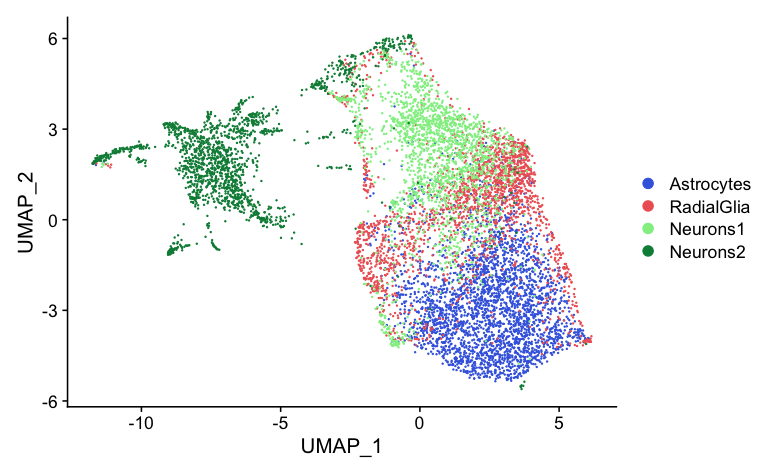

```r
DimPlot(seu.sc, order = sample.order, cols = clust.colours, shuffle = TRUE, raster=FALSE, pt.size = 0.1, label = FALSE, label.size = 6) +
  theme(legend.text = element_text(size=16), axis.title.y = element_text(size=16),
        axis.title.x = element_text(size=16), axis.text.y = element_text(size =16),
        axis.text.x = element_text(size =16))
dev.off()
```

```r
## Figure S23 panel

cell.order <- c("Astrocytes","Endothelial","Glia","NPC","Neurons","Other","Radial Glia")
cell.order <- rev(cell.order)

# colour order to match cell type order
clust.colours <- c("chocolate1","deepskyblue","steelblue4","red2","mediumpurple3","burlywood3",
                   "pink2")


Idents(seu.sc) <- 'Cell_Types'

# designated the order of the splits factor
seu.sc$orig.ident <- factor(x = seu.sc$orig.ident, levels = c("Astrocytes","RadialGlia","Neurons1","Neurons2"))


DimPlot(seu.sc, order = cell.order, cols = clust.colours, shuffle = TRUE, raster=FALSE, pt.size = 0.1, label = FALSE, split.by = 'orig.ident', ncol = 2)




pdf(paste(output_path,"UMAP_merge_splitbyorigidentOct16.pdf"),width = 12, height = 7.5)
```

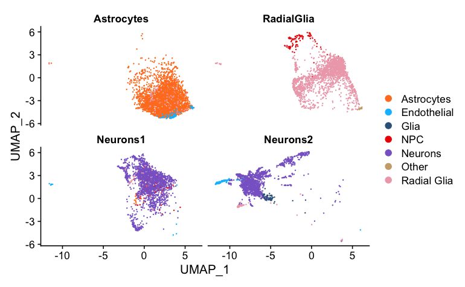

```r
DimPlot(seu.sc, order = cell.order, cols = clust.colours, shuffle = TRUE, raster=FALSE, pt.size = 0.1, label = FALSE, split.by = 'orig.ident', label.size = 6, ncol = 2) +
  theme(legend.text = element_text(size=16), axis.title.y = element_text(size=16),
        axis.title.x = element_text(size=16), axis.text.y = element_text(size =16),
        axis.text.x = element_text(size =16))
dev.off()
```

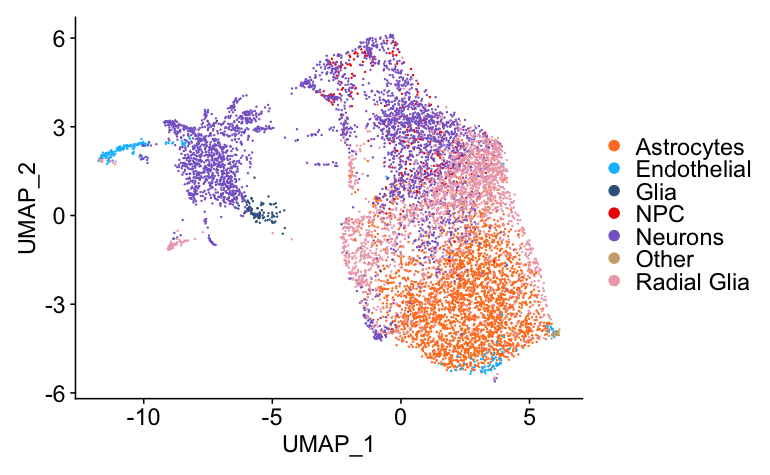

```r
# also plot one not split to see the whole thing


#pdf(paste(output_path,"UMAP_merge_CellTypesOct16.pdf"),width = 6.7, height = 4.1)
DimPlot(seu.sc, order = cell.order, cols = clust.colours, shuffle = TRUE, raster=FALSE, pt.size = 0.1, label = FALSE, label.size = 6) +
  theme(legend.text = element_text(size=16), axis.title.y = element_text(size=16),
        axis.title.x = element_text(size=16), axis.text.y = element_text(size =16),
        axis.text.x = element_text(size =16))
```

```r
#dev.off()
```

Figure 6D - UMAP with subgroups

```r
pdf(paste(output_path,"UMAP_CellSubtypeMarkersLablesOct16.pdf"),width = 12, height = 5)
DimPlot(seu.sc, order = sample.order, cols = clust.colours, shuffle = TRUE, raster=FALSE, pt.size = 0.25, label = TRUE, repel = TRUE)
dev.off()
```

Make a heatmap

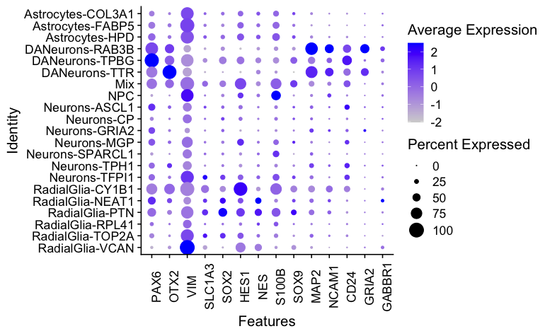

[figure not shown]

Heatmap or Dotplot Save pdf

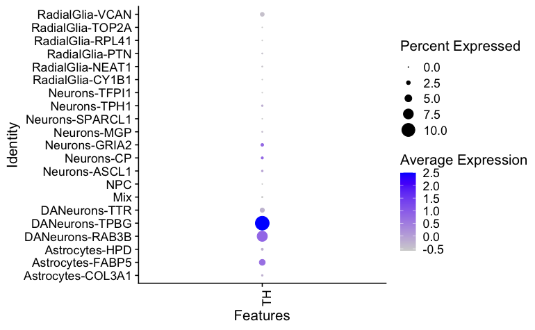

save the heatmap Change the colours

```r
pdf(paste(output_path,"HeatMapsubtypesOct17.pdf",sep = ""),width = 11, height = 5)
DoHeatmap(seu.sc, features = feature_list, group.by = 'Cell_Subtype_Markers', group.colors = clust.colours, disp.max = 2, disp.min = -1.5,
          angle = 90) + scale_fill_gradientn(colors = c("#154c79", "#eeeee4", "#e28743")) +
  theme(axis.text.y = element_text(size = 16))
```

[output not shown]

```r
dev.off()
```

Subtype markers

```r
Idents(seu.sc) <- 'Cell_Subtypes'
neurons <- subset(seu.sc, idents = c("Neurons1","Neurons2","Neurons3","Neurons4",
                                     "Neurons5","Neurons6","Neurons7"))

Idents(neurons) <- 'Cell_Subtype_Markers'

pdf(paste(output_path,"UMAP_NeuronsOct17.pdf",sep = ""),width = 7, height = 4)
DimPlot(neurons) +  theme(text = element_text(size=16, colour = "black"))
dev.off()
```

```r
Idents(seu.sc) <- 'Cell_Subtypes'
neurons.da <- subset(seu.sc, idents = c("DANeurons1","DANeurons2","DANeurons3"))

Idents(neurons.da) <- 'Cell_Subtype_Markers'
pdf(paste(output_path,"UMAP_DANeuronsOct17.pdf",sep = ""),width = 7, height = 4)
```

```r
DimPlot(neurons.da)+  theme(text = element_text(size=16, colour = "black"))
dev.off()
```

```r
Idents(seu.sc) <- 'Cell_Subtypes'
astro <- subset(seu.sc, idents = c("Astrocytes1","Astrocytes2","Astrocytes3"))
Idents(astro) <- 'Cell_Subtype_Markers'
pdf(paste(output_path,"UMAP_AstroOct17.pdf",sep = ""),width = 7, height = 4)
```

```r
DimPlot(astro)+  theme(text = element_text(size=16, colour = "black"))
dev.off()
```

```r
Idents(seu.sc) <- 'Cell_Subtypes'
rg <- subset(seu.sc, idents = c("RadialGlia1","RadialGlia2","RadialGlia3","RadialGlia4",
                                "RadialGlia5","RadialGlia6"))
Idents(rg) <- 'Cell_Subtype_Markers'
pdf(paste(output_path,"UMAP_RGOct17.pdf",sep = ""),width = 7, height = 4)
```

```r
DimPlot(rg)+  theme(text = element_text(size=16, colour = "black"))
dev.off()
```

DotPlots of markers in cell type subsets

```r
n.markers <- c("ASCL1","CP","GRIA2","MGP","SPARCL1","TPH1","TFPI2","CD24")

pdf(paste(output_path,"Dotplot_NeuSubMarkersOct17.pdf",sep = ""),width = 7, height = 4)
DotPlot(neurons, features = n.markers) +
  theme(text = element_text(size=16, colour = "black"),axis.text.x = element_text(angle = 90))
dev.off()
```

```r
da.markers <- c("RAB3B","TPBG","TTR","TH","SOX6","CALB1","SLC17A6")

pdf(paste(output_path,"Dotplot_DANeuSubMarkersOct17.pdf",sep = ""),width = 7, height = 4)
```

```r
DotPlot(neurons.da, features = da.markers) +
  theme(text = element_text(size=16, colour = "black"),axis.text.x = element_text(angle = 90))
dev.off()
```

```r
rg.markers <- c("CYP1B1","NEAT1","PTN","RPL41","TOP2A","VCAN","SOX2","SLIT2","HES1","VIM")

pdf(paste(output_path,"Dotplot_RGMarkersOct17.pdf",sep = ""),width = 7, height = 4)
```

```r
DotPlot(rg, features = rg.markers) +
  theme(text = element_text(size=16, colour = "black"),axis.text.x = element_text(angle = 90))
dev.off()
```

```r
# Apoe, Gfap, Aqp4 and Slc1a3
astro.markers <- c("COL3A1","FABP5","HPD","APOE","S100B","IGFBP2","DBI",
                   "PRSS56", "IGTP","LFIT3","LIGP1",
                   "COL1A2")

pdf(paste(output_path,"Dotplot_AstroMarkersOct17.pdf",sep = ""),width = 7, height = 4)
```

```r
DotPlot(astro, features = astro.markers) +
  theme(text = element_text(size=16, colour = "black"),axis.text.x = element_text(angle = 90))
dev.off()
```

Make a label level of main cell types from the merge data

```r
unique(seu.sc$Cell_Subtype_Markers)
```

```
 [1] Neurons-GRIA2     NPC               Neurons-SPARCL1   DANeurons-TPBG    Neurons-CP
 [6] DANeurons-RAB3B   DANeurons-TTR     RadialGlia-CY1B1  RadialGlia-RPL41  RadialGlia-PTN
[11] Astrocytes-FABP5  Astrocytes-HPD    RadialGlia-TOP2A  Mix               Neurons-TPH1
[16] Neurons-TFPI1     Neurons-ASCL1     RadialGlia-NEAT1  RadialGlia-VCAN   Neurons-MGP
[21] Astrocytes-COL3A1
21 Levels: Astrocytes-HPD Neurons-ASCL1 RadialGlia-RPL41 Neurons-SPARCL1 ... RadialGlia-VCAN
```

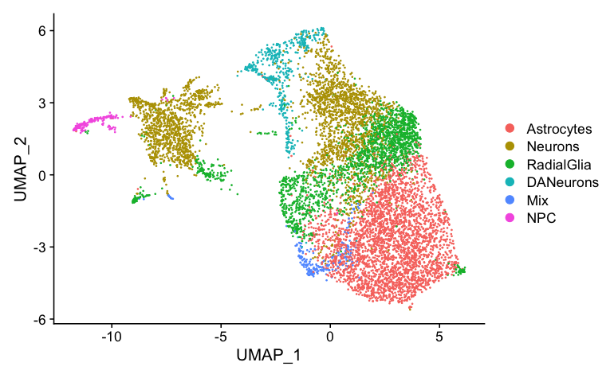

```r
Idents(seu.sc) <- 'Cell_Subtype_Markers'

cluster.ids <- c("Astrocytes","Neurons","RadialGlia","Neurons",
                 "Astrocytes","Neurons","RadialGlia","Neurons",
                 "Astrocytes","Neurons","RadialGlia",
                 "DANeurons","Neurons","Mix","NPC",
                 "Neurons","DANeurons","DANeurons",
                 "RadialGlia","RadialGlia","RadialGlia"
                 )


names(cluster.ids) <- levels(seu.sc)
seu.sc <- RenameIdents(seu.sc, cluster.ids)
seu.sc$Cell_Type2 <- Idents(seu.sc)
Idents(seu.sc) <- 'Cell_Type2'
DimPlot(seu.sc)
```

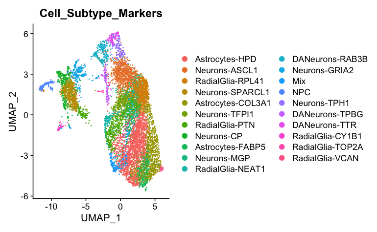

```r
DimPlot(seu.sc, group.by = 'Cell_Subtype_Markers')
```

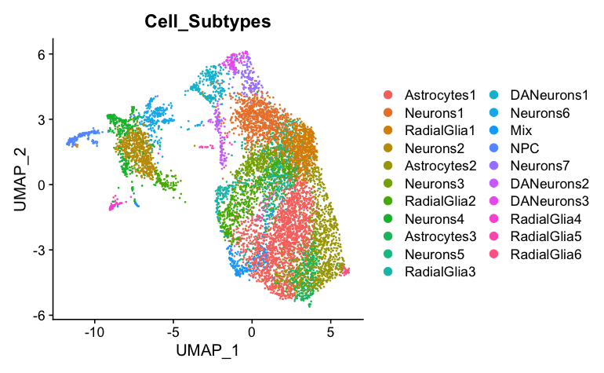

```r
DimPlot(seu.sc, group.by = 'Cell_Subtypes')
```

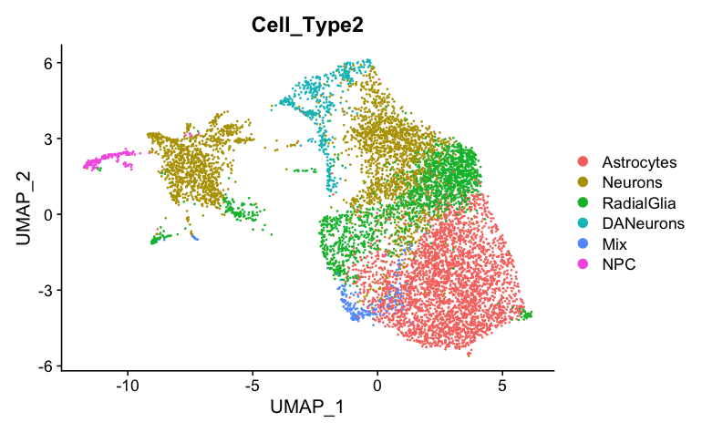

```r
DimPlot(seu.sc, group.by = 'Cell_Type2')
```

```r
NA
NA
```

```r
# original clusters proportion of cell types in
library(reshape2)

pr.celltypes <- as.data.frame(table(seu.sc$orig.ident,seu.sc$Cell_Type2))
pr.celltypes <- reshape(pr.celltypes, idvar = "Var2", timevar = "Var1", direction = "wide")
pr.celltypes
```

|  | Var2 | Freq.Neurons2 | Freq.Neurons1 | Freq.Astrocytes | Freq.RadialGlia |
| --- | --- | --- | --- | --- | --- |
| 1 | Astrocytes | 13 | 80 | 2606 | 383 |
| 5 | Neurons | 1153 | 1428 | 142 | 147 |
| 9 | RadialGlia | 196 | 256 | 161 | 1300 |
| 13 | DANeurons | 206 | 146 | 7 | 117 |
| 17 | Mix | 15 | 84 | 81 | 48 |
| 21 | NPC | 140 | 6 | 3 | 5 |

```r
table(seu.sc$Cell_Type2)
```

```
Astrocytes    Neurons RadialGlia  DANeurons        Mix        NPC
      3082       2870       1913        476        228        154
```

```r
write.csv(pr.celltypes, paste(output_path,"FreqCellTypes2inFACS.csv"))
```

Proportion of cell types in original FACS populations

```r
pr
```

```
                     1          22         43           64
Var2                 "Neurons2" "Neurons1" "Astrocytes" "RadialGlia"
Freq.DANeurons-RAB3B "131"      " 76"      "  0"        " 52"
Freq.DANeurons-TPBG  "10"       "50"       " 7"         "46"
Freq.DANeurons-TTR   "65"       "20"       " 0"         "19"
```

Proportion of cell types tests

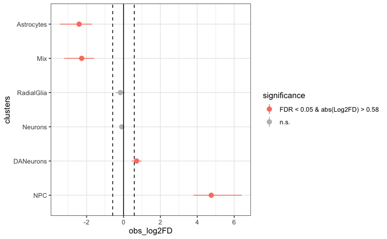

```r
library("scProportionTest")

prop_test <- sc_utils(seu.sc)

prop_test <- permutation_test(
    prop_test, cluster_identity = "Cell_Type2",
    sample_1 = "Neurons1", sample_2 = "Neurons2",
    sample_identity = "orig.ident"
)


permutation_plot(prop_test)
```

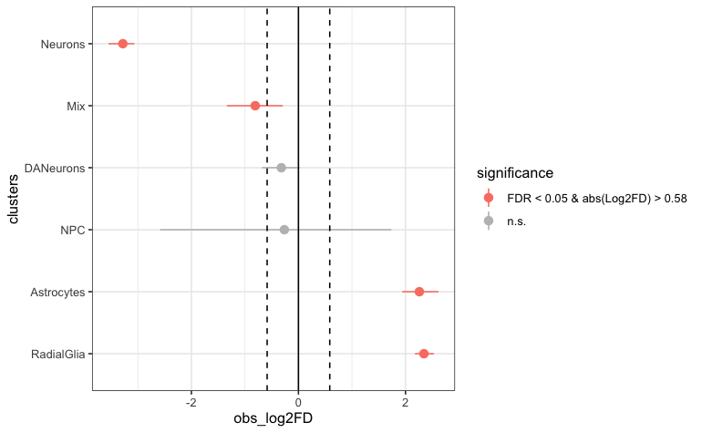

```r
prop_test <- permutation_test(
    prop_test, cluster_identity = "Cell_Type2",
    sample_1 = "Neurons1", sample_2 = "RadialGlia",
    sample_identity = "orig.ident"
)
permutation_plot(prop_test)
```

```r
prop_test <- permutation_test(
    prop_test, cluster_identity = "Cell_Type2",
    sample_1 = "Neurons2", sample_2 = "RadialGlia",
    sample_identity = "orig.ident"
)
```

[output not shown]

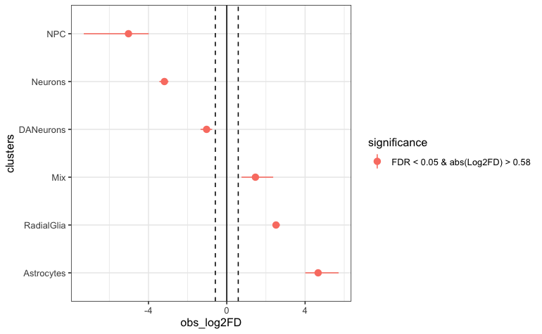

```r
permutation_plot(prop_test)
```

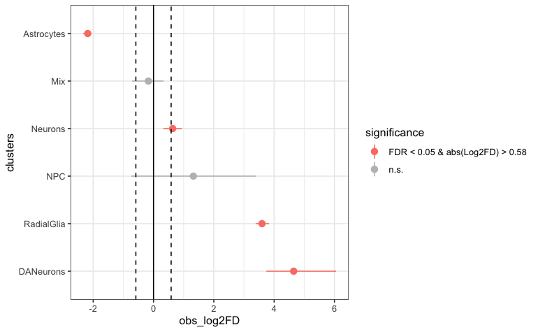

```r
prop_test <- permutation_test(
    prop_test, cluster_identity = "Cell_Type2",
    sample_1 = "Astrocytes", sample_2 = "RadialGlia",
    sample_identity = "orig.ident"
)
permutation_plot(prop_test)
```

Check the proportions of subtypes of DA neurons

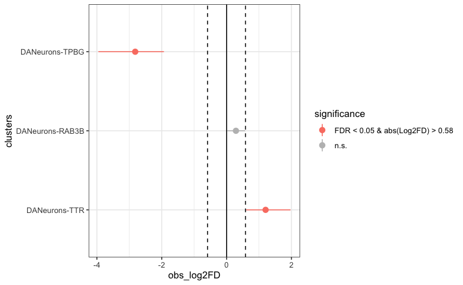

```r
#library("scProportionTest")

prop_test <- sc_utils(neurons.da)

prop_test <- permutation_test(
    prop_test, cluster_identity = "Cell_Subtype_Markers",
    sample_1 = "Neurons1", sample_2 = "Neurons2",
    sample_identity = "orig.ident"
)


permutation_plot(prop_test)
```

Differential gene expression between Neurons1 and Neurons2 for Other neurons and DA neurons.

```r
down <- rownames(deg.neurons %>% filter(avg_log2FC < -6))
length(down)
```

```
[1] 8
```

In DA neurons

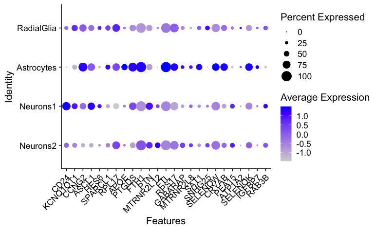

```r
DotPlot(sub.neur, group.by = 'orig.ident', features = up.down) + RotatedAxis()
```

Look at the GO and other pathway analysis for the DGE

| Term | Overlap | P.value | Adjusted.P.value | Old.P.value | Old.Adjusted.P.value | Odds.Ratio | Combined.Score | Genes |
| --- | --- | --- | --- | --- | --- | --- | --- | --- |
| mitochondrial ATP synthesis coupled electron transport (GO:0042775) | 11/86 | 9.674575e-20 | 2.573437e-17 | 0 | 0 | 171.6603922 | 7.515670e+03 | MT-ND6;MT-ND4L;MT-ND4;MT-ND5;MT-CO1;MT-CO2;MT-CO3;MT-ND2;MT-CYB;MT-ND3;MT-ND1 |
| respiratory electron transport chain (GO:0022904) | 11/95 | 3.066339e-19 | 4.078230e-17 | 0 | 0 | 153.1988796 | 6.530659e+03 | MT-ND6;MT-ND4L;MT-ND4;MT-ND5;MT-CO1;MT-CO2;MT-CO3;MT-ND2;MT-CYB;MT-ND3;MT-ND1 |
| mitochondrial electron transport, NADH to ubiquinone (GO:0006120) | 7/47 | 2.827998e-13 | 2.507491e-11 | 0 | 0 | 166.1000000 | 4.799300e+03 | MT-ND6;MT-ND4L;MT-ND4;MT-ND5;MT-ND2;MT-ND3;MT-ND1 |
| NADH dehydrogenase complex assembly (GO:0010257) | 6/65 | 3.312839e-10 | 1.468692e-08 | 0 | 0 | 92.0477658 | 2.009223e+03 | MT-ND6;MT-ND4;MT-ND5;MT-ND2;MT-ND3;MT-ND1 |
| mitochondrial respiratory chain complex I biogenesis (GO:0097031) | 6/65 | 3.312839e-10 | 1.468692e-08 | 0 | 0 | 92.0477658 | 2.009223e+03 | MT-ND6;MT-ND4;MT-ND5;MT-ND2;MT-ND3;MT-ND1 |
| mitochondrial respiratory chain complex I assembly (GO:0032981) | 6/65 | 3.312839e-10 | 1.468692e-08 | 0 | 0 | 92.0477658 | 2.009223e+03 | MT-ND6;MT-ND4;MT-ND5;MT-ND2;MT-ND3;MT-ND1 |
| mitochondrial respiratory chain complex assembly (GO:0033108) | 6/98 | 4.092332e-09 | 1.555086e-07 | 0 | 0 | 58.9328063 | 1.138237e+03 | MT-ND6;MT-ND4;MT-ND5;MT-ND2;MT-ND3;MT-ND1 |
| cellular respiration (GO:0045333) | 4/58 | 1.237425e-06 | 4.114440e-05 | 0 | 0 | 61.4753086 | 8.362165e+02 | MT-ND4;MT-CO1;MT-CO3;MT-ND1 |
| mitochondrial electron transport, cytochrome c to oxygen (GO:0006123) | 3/21 | 3.213341e-06 | 9.497207e-05 | 0 | 0 | 133.0266667 | 1.682548e+03 | MT-CO1;MT-CO2;MT-CO3 |
| SRP-dependent cotranslational protein targeting to membrane (GO:0006614) | 4/90 | 7.226989e-06 | 1.922379e-04 | 0 | 0 | 38.5387597 | 4.562098e+02 | RPS17;RPL36A;RPS10;RPL17 |

[output cut: 256 more lines]

For DA neurons

```r
pdf(paste(output_path,"GOresultesNeurons1vs2.pdf"), width = 12, height = 6)
plotEnrich(t.GObio.da1, showTerms = 10, numChar = 40, y = "Count", orderBy = "Combined.Score") +
  theme(text = element_text(size=16, colour = "black"))
plotEnrich(t.GObio.da1, showTerms = 10, numChar = 40, y = "Count", orderBy = "Overlap")+
  theme(text = element_text(size=16, colour = "black"))
plotEnrich(t.GObio.da2, showTerms = 10, numChar = 40, y = "Count", orderBy = "Combined.Score")+
  theme(text = element_text(size=16, colour = "black"))
plotEnrich(t.GObio.da2, showTerms = 10, numChar = 40, y = "Count", orderBy = "Overlap")+
  theme(text = element_text(size=16, colour = "black"))
dev.off()
```

Dot plots of some up regulated genes

```r
DotPlot(all.neurons, group.by = 'orig.ident', features = regulate.genes) + RotatedAxis()
pdf(paste(output_path,"DotPlotDEG_N1vsN2.pdf"))
```

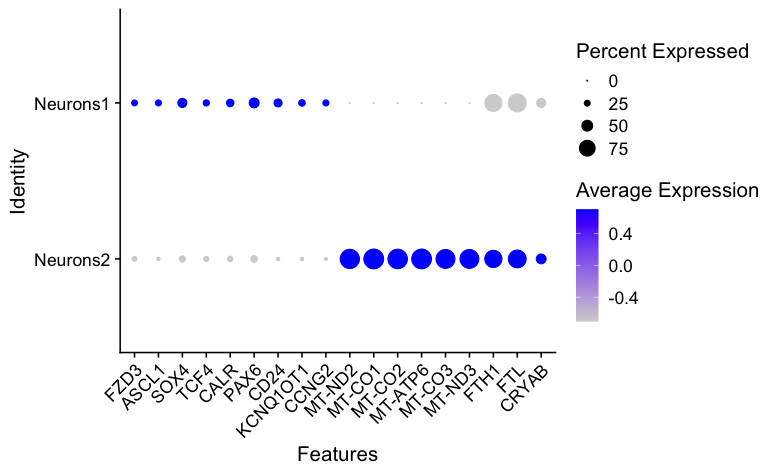

```r
DotPlot(all.neurons, group.by = 'orig.ident', features = regulate.genes) + RotatedAxis()
dev.off()
```

```r
BiocManager::install("clusterProfiler")
n
BiocManager::install("pathview")
n
BiocManager::install("enrichplot")
n
library(clusterProfiler)
library(enrichplot)
# we use ggplot2 to add x axis labels (ex: ridgeplot)
library(ggplot2)
```

Try with cluster profiler

```r
emapplot(gse, showCategory = 10)
```

```
Error in has_pairsim(x) :
  Term similarity matrix not available. Please use pairwise_termsim function to deal with the results of enrichment analysis.
```